# Exponential Distribution vs Central Limit Theorem

Sunil Samson S

10/16/2020

## Overview

The motivation behind this examination is to explore the exponential distribution vs Central Limit theorem. For this analysis, the lambda will be set to 0.4 for the entirety of reenactments. This analysis will look at the distribution of midpoints of 50 exponentials for more than 1000 simulations.

## Simulation

Set the simulation variables, lambda, exponentials and seed.

```r
ECHO=TRUE
set.seed(2116)
lambda = 0.4
exponentials = 50
```

Run Simulations with variables.

```r
simMeans = NULL
for (i in 1 : 1000) simMeans = c(simMeans, mean(rexp(exponentials, lambda)))
```

## Sample Mean vs Theoritical Mean

#### Sample Mean

Ascertaining the mean from the recreations with give the example mean.

```r
mean(simMeans)
```

```
## [1] 2.515124
```

#### Theoritical Mean

The hypothetical mean of an exponential circulation is lambda^-1.

```r
lambda^-1
```

```
## [1] 2.5
```

#### Comparision

There is just a slight distinction between the simulations sample mean and the exponential distribution theoritical mean.

```r
abs(mean(simMeans)-lambda^-1)
```

```
## [1] 0.01512377
```

## Sample Variance vs Theoretical Variance

#### Sample Variance

Calculating the variance from the simulation means with the sample variance.

```r
var(simMeans)
```

```
## [1] 0.128391
```

### Theoretical Variance

The theoretical variance of exponential distribution is given by (lambda * sqrt(n))^-2.

```r
(lambda * sqrt(exponentials))^-2
```

```
## [1] 0.125
```

#### Comparison

There is just a slight variation between the simulations sample variance and the exponential distribution theoretical variance.

```r
abs(var(simMeans)-(lambda * sqrt(exponentials))^-2)
```

```
## [1] 0.003391004
```

## Distribution

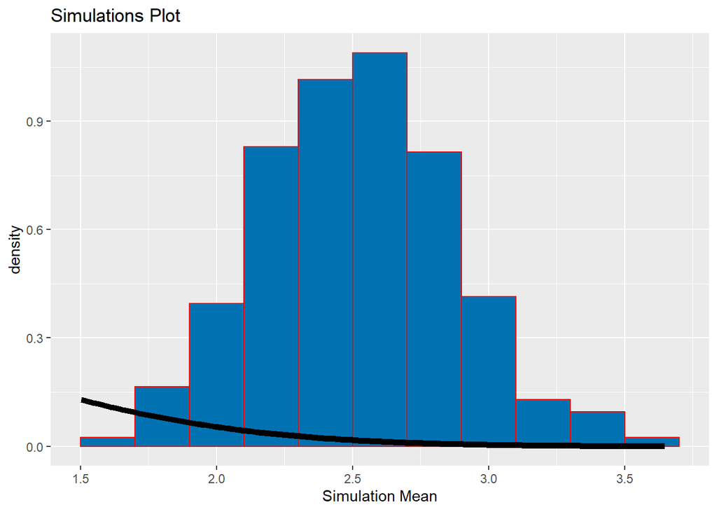

```r
library(ggplot2)
ggplot(data.frame(y=simMeans), aes(x=y)) +
  geom_histogram(aes(y=..density..), binwidth=0.2, fill="#0072B2",
                 color="red") +
  stat_function(fun=dnorm, arg=list(mean=lambda^-1,
                                    sd=(lambda*sqrt(exponentials))^-1),
                size=2) +
  labs(title="Simulations Plot", x="Simulation Mean")
```